# Crispr Cas-9

Msc.Ali Mertcan KÖSE

Supervisor: PhD.Ozan KOCADAĞLI

# Crispr Cas-9

**CRISPR (Clustered Regularly Interspaced Short Palindromic Repeats):** *“Düzenli Aralıklarla Bölünmüş Palindromik Tekrar Kümeleri”*

- DNA dizisi üzerinde, Crispr lokosu(Bir genin kromozonda düştüğü yerdir) tanımlayan gen dizilimidir. Tekrar diziler bir canlı için tamamen aynı olmakla beraber tekrarların arasındaki dizileri birbirinden farklılık göstermektedir.

**Cas:** Bu bağışıklılık sisteminde görev alan proteinlerin genel adıdır.

# Crispr Cas-9

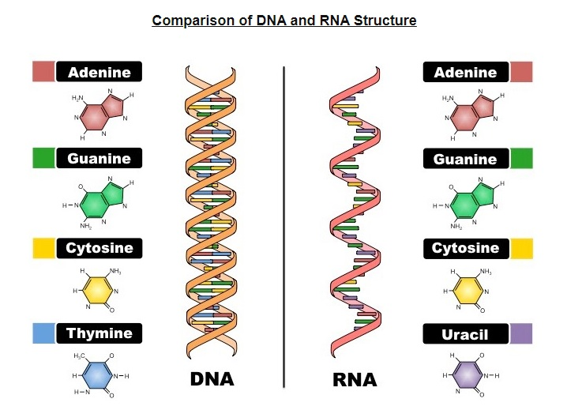

DNA vs RNA.

# Crispr Cas-9

Virüs DNA’sını Crispr denilen DNA arşivinde saklıyor. Burada, ihtiyaç olunana dek saklanıyor. Virüs tekrar saldırdığında, Bakteri DNA arşivinden hemen bir RNA kopyası çıkartıyor, ve gizli bir silah kuşanıyor. Buna CAS-9 proteini deniyor. Protein bakterinin içini istilacıdan bir iz bulmak için tarıyor. Her parçayı arşivdeki örnekle karşılaştırarak mükemmel uyuşmayı bulduğunda da aktive oluyor ve virüs DNA’sını kesiyor. Saldırıya karşı bakterinin kendisini korumasını yararsız yapıyor. Bu yüzden Cas-9’u özel yapan şey tamamen kusursuz olması, ve neredeyse DNA içinde bir cerrah edası yaratmasıdır. Asıl önemli olan olay, Crispr’nın progranabilir olduğu zaman başlıyor. “Düzenlemek istediğin DNA’nın kopyasını ver ve sisteme yaşayan bir hücreye koy.”

# Crispr Cas-9

Eğer genetik manipulasyonun eski tekniği haritaysa Crispr ise GPS gibidir. Kusursuz, ucuz ve kolay olmasının yanı sıra, Crispr yaşayan hücreleri düzenleme imkanı sunuyordur. Genleri açıp kapatmaya ve hedef belirleyip özel DNA’ları çalışmaya kadar.Ayrıca her türlü hücrede çalışabilir(Mikroorganizma, bitki, hayvan ya da insan). Crispr bu anlamda DNA yapısını değiştiren bir yapıdır, yalnız buradaki önemli husus ise bu haritada en iyi modelleme yaparak en iyi DNA üzerindeki zarar görmüş hücre yapılarını en iyi şekilde düzenlemektir.

# Crispr Cas-9

**Cas-9:** *CS.pyogenes* Cas9 geniş(1368 aminoasit) çoklu alanlara sahip ve multifonksiyonel DNA endonükleazdır.

**gRNA:** Cas bağlanması için gerekli olan iskele dizisinden ve değiştirilecek genomik hedefi tanımlayan 20 aralıklı nükleotidden oluşan kısa sentetik bir RNA dır

**PAM:** Pam dizilimi Cas9 için bağlayıcı bir sinyal görevinde bulunur, ancak bu tam dizilim kullanılan Cas proteinine bağlıdır. Böylece hedef dizilimi bulmada PAM’in tanımlanmasını büyük rolü vardır. Burada PAM dizilimin sistematik 3 lü nükleotid dizilimi göz önünde bulundururularak hedef dizilimi hakkında eşleme yapılır. Böylece Crispr çalışmalarında Cas9 kullanalarak, PAM dizilimi üzerinden işlem yapılacak(mutasyon/ekleme/çıkarma) hedef dizilimi eşlemesi yapılır.

# Crispr Cas-9

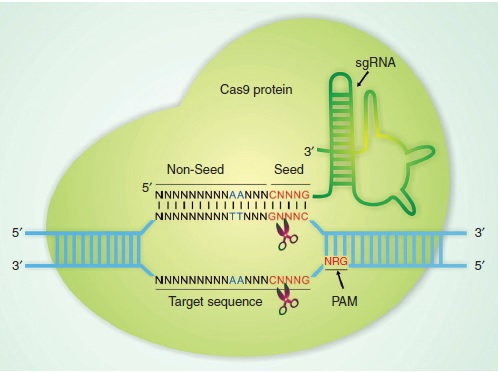

Crispr Cas-9 Sistemi.

# Crispr Cas-9

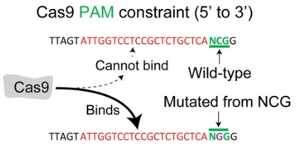

PAM dizilimi.

# Crispr Cas-9

[figure not shown]

Cas-9.

# Crispr Cas-9

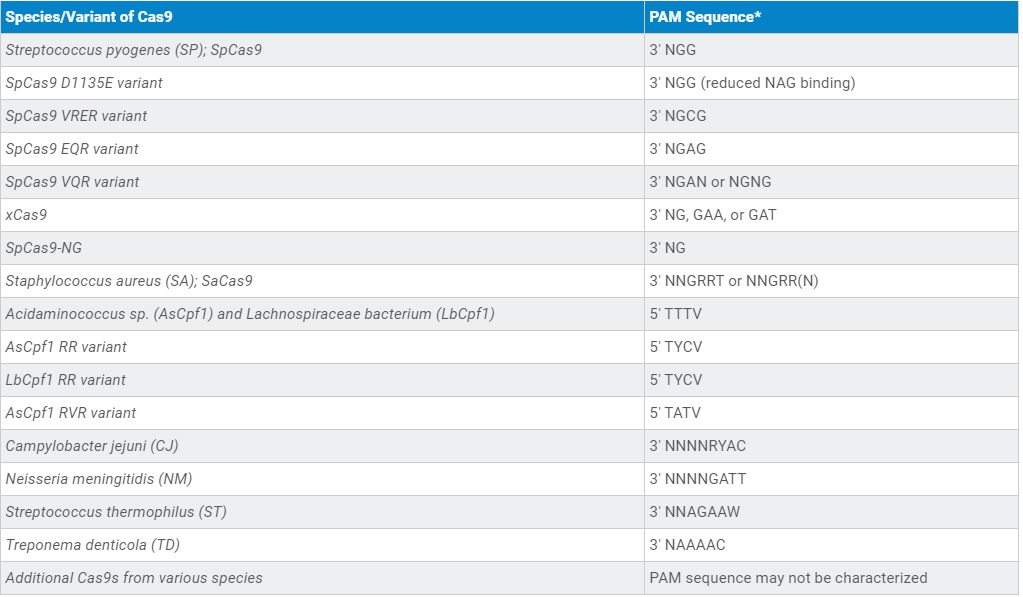

Cas proteinine göre PAM dizilimi.

# Crispr Cas-9

**Target On:** gRNA hedef dizisi tarafından belirtilen istenen bir konumda Cas9 bölünmesi aktivitesine “Target On” denir.

**Target Off:** Cas9’u istenmeyen genomik konumlara almak için yeterli homolojiye sahip gRNA hedefleme dizisi nedeniyle istenmeyen yerlerdeki Cas9 bölünmesi.

# Crispr Cas-9

### Homoloji olmayan modelleme

(NHEJ) homolog olmayan uç birleştirmedir. Genellikle bu birleştirme yöntemiyle dominant alleli bozmak için kullanılır. Eğer hastalık bir genin işlev kaybetmesi ile oluşuyorsa, HDR ile donör kalıp üzerinde genin düzgün işleve sahip olanının kopyası kullanılark düzeltilebilir

# Crispr Cas-9

**Gene Knockin:** Genetik anlamda hücreyi onarmanın bir diğer yolu ise **Gene Knockin** metotudur.Burada homolojik bir yaklaşım vardır.

### Homoloji modelleme

(HDR)Homoloji modelleme yöntemi x-ray cyrstallograph ya da MR çalışmalarıyla deneysel olarak yapısı belirlenmiş bir proteinin kalıp olarak kullanılıdğı, benzerliklerden yola çıkılarak hedef proteinin 3 boyutlu yapısının belirlendiği bir yaklaşımdır. DNA donörüyle birlikte verildiğinde Beta katenin kodlayan gende spesifik nokta mutasyonu olduğu ve bu stratejinin daha kesin genom düzenleme süreçlerinde kullanabileceği yöntemlerden biridir.

# Crispr Cas-9

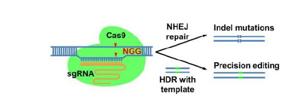

Knockout-Knockin.

# Crispr Cas-9

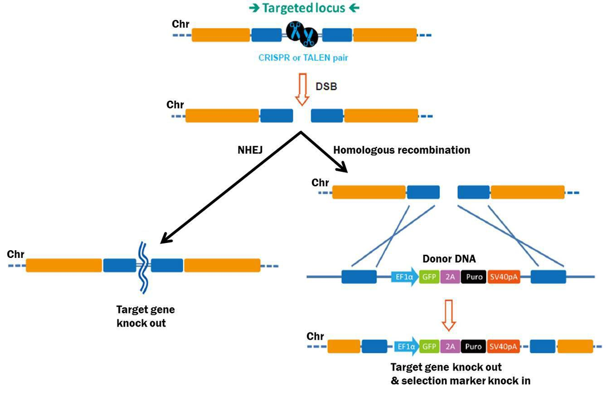

Knockout vs Knockin.

# Crispr Cas-9

- Domain-Specific introduction to machine learning terminology, pitfalls and oppurtunities in Crispr-based gene editing
  - Amaç: Machine learning algoritmaları ile gende hedeflenen pozisyonu ve hedeflenen akson gibi özelliklerini içeren poziyonlar ile belirlenen modeller ile Crispr Ve Azimuth yaklaşımlarıyla geliştirmektir. Böylece Cas-9’un istenmeyen nükleaz lokusu üzerindeki lokasyonu tahmin edilebilir. (**Features:** Cell line, SgRNA, Chromosome, Start, End, Target Gene, SgRNA Sequence, Direction, PubMed ID, Read Count final replicate1,Read Count final replicate2, Read count şnitial replicate, Gene score, Expreiment Type, Hit)

# Crispr Cas-9

- A machine learning approach for predicting Crispr-Cas9 cleavage efficiencies and patterns underlying its mechanism of action
  - Amaç: Crispr-Cas9’un bölünme etkinliğini potansiyel olarak etkileyen özellikleri incelemektir. DNA ve RNA dizilimi göz önünde bulundurularak off-target diziliminin Machine learning algoritmalarıyla tahmin edilmesidir.(**Features:**Study, Ontarget title, SgRNA sequence, DNA site strand, strand, coordinate(start-end), chromosone, mismatch, nuckeotide-position, etc. )

# Crispr Cas-9

| On target Software | Model | PAM |
| --- | --- | --- |
| DeepCRISPR | CNN^1 | NGG |
| DeepCpf1 | CNN | TTTN |
| DeepCas9 | CNN | NGG |
| CRISPRater | L1-reg | NGG |
| WU-CRISPR | SVM | NGG |
| SgRNAScorer | SVM(C) | NGG,NAG |
|  |  | NNAGAAW,NNNNGMTT |

# Crispr Cas-9

Crispr cas-9 tanıtım videosu [link](https://www.youtube.com/watch?v=4YKFw2KZA5o)

# Referans

- Jiang, F., Doudna J.A.(2017).Crispr-Cas9 Structures and Machanisms, *Annual Review Biophys*, 46:505-29.
- https://www.nature.com/articles/d41586-020-00903-x
- https://www.addgene.org/guides/crispr/
- Hui, D.Y. (1998). Utility and Importance of Gene Knockout Animals For Nutritional and Metabolic Research, *The Journal of Nutrition*, 128(11),2052-2057.
- Roebroek, A.J.M, Gordts, P.L.S, Reekmans, S. (2011).Transgenic Mouse Methods and Protocols, Humana Press, New York. pp.257-275.